# Untitled

### Characterization of the Data Set

Overall, there are 71 samples in this experiment. Samples were divided into two groups (Control and Mucin-supplemented) and three different timepoints (pre-stress, 3 weeks post-stress, and 4 weeks post-stress). Importantly, Mucin treatment does not start until Week 4, so Control and Mucin-supplemented groups are identical at baseline and 3 weeks post-stress. There are 12 mice for each group/timepoint, but Sample #167 was removed due to low read counts, giving our 71 samples.

Below are a general overview of the total number of reads in the data set, the meaan and median number of reads/sample, and the range of reads across this data set.

```r
sum(total.reads)
```

```
## [1] 4784563
```

```r
mean(total.reads)
```

```
## [1] 67388.21
```

```r
median(total.reads)
```

```
## [1] 66966
```

```r
range(total.reads)
```

```
## [1]  39993 101514
```

### Alpha Diversity

I’ll first investigate alpha diversity, which examines diversity within a given sample. Alpha diversity consists of two major measures:

- **Richness**: the number of taxonomic groups within a given sample.
- **Evenness**: how evenly abundances of taxonomic groups are distributed in a given sample.

The DADA2 pipeline removes singlets (sequences detected only once) and doublets (sequences detected twice) from the data set, as it does not have enough confidence to determine whether these sequences are real or artifacts. Because of this, measures of richness fail explicitly and are difficult to interpret. I’ll focus mainly on measures of evenness but give measures of richness a glance to see if there are any major differences.

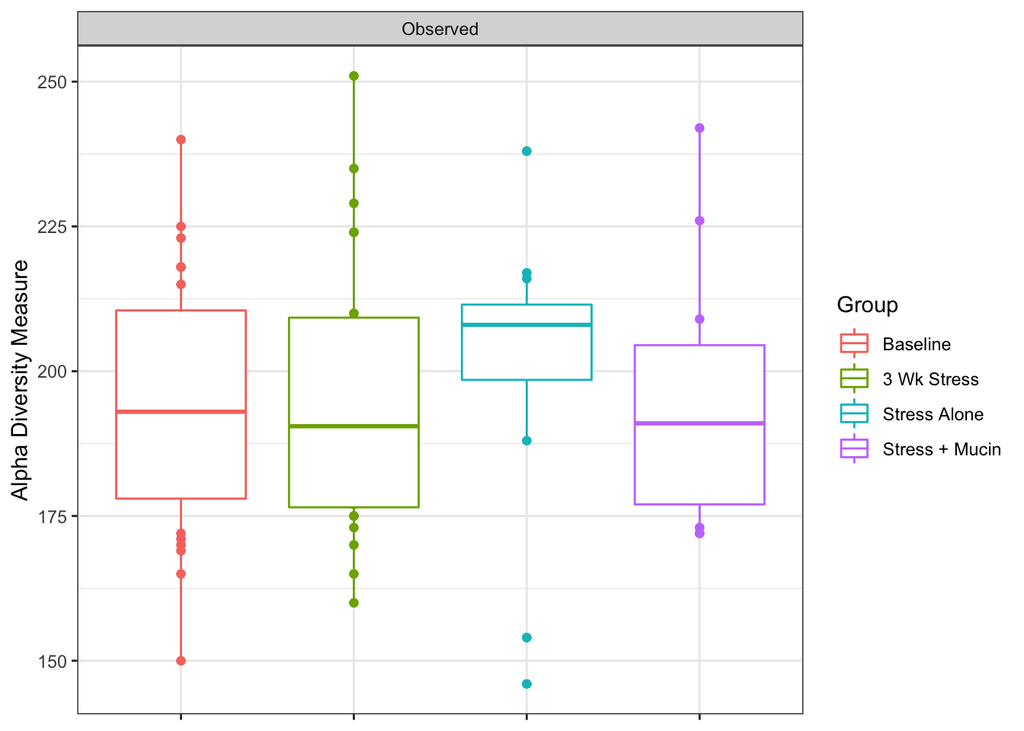

```
##
##  Pairwise comparisons using Wilcoxon rank sum test with continuity correction
##
## data:  richness$Observed and sample_data(ps.mucin)$Group
##
##                Baseline 3 Wk Stress Stress Alone
## 3 Wk Stress    1        -           -
## Stress Alone   1        1           -
## Stress + Mucin 1        1           1
##
## P value adjustment method: bonferroni
```

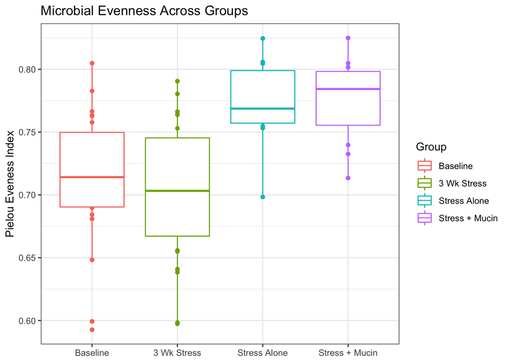

[output not shown]

```
##
##  Pairwise comparisons using Wilcoxon rank sum exact test
##
## data:  evenness$pielou and sample_data(ps.mucin)$Group
##
##                Baseline 3 Wk Stress Stress Alone
## 3 Wk Stress    1.0000   -           -
## Stress Alone   0.0023   0.0005      -
## Stress + Mucin 0.0023   0.0011      1.0000
##
## P value adjustment method: bonferroni
```